# Generate a read count matrix using <code>htseq-count</code>

\newpage

## Generate a read count matrix using `htseq-count`

Sample command:

`htseq-count -f bam -r name -t CDS -o scaffold.htseq.sam -i ID -q scaffold_sortedByName.bam all_combined.gff`

This command was run for each sample individually.

### Merging duplicate genes

I performed a self blast and looked at results that had a percent identity greater than 98%, query coverage greater than 96% and a minimum alignment length of 500 bases. Once I had this subset, I screened out the hits to exons since we won't be considering them for this experiment anyway. I was left with the following two gene pairs:

- scaffold*344578**MIS_1109813.1 scaffold_133898*_MIS_10093600.14
- scaffold*219988**MIS_10179608.12 scaffold_555373*_MIS_1172265.1

that had high enough similarity based on the thresholds mentioned above that their count data needed to be merged. The perl script `mergeCounts.pl` was run on each htseq-count output individually in order to accomplish this. Here is a sample command used for one of the htseq-count outputs:

`perl mergeCounts.pl -l realDuplicateGenes.list -tsv Day_1.htseqCount.tsv -o Day_1.htseqCount.merged.tsv`

where, realDuplicateGenes.list contains the two gene pairs mentioned above.

### Import Counts into DESeq2

Once we were satisfied with the genes and their counts. We imported the count data into DESeq2.

## Reads per Sample

```
##   Day_1   Day_2   Day_3 Night_4 Night_5 Night_6
## 2739735  492104  691689 1105737 1587917  969992
```

### Filtering the data

Get rid of genes which did not occur frequently enough. Here we say, lets get rid of genes with counts >=1 in at least 2 samples.

```
##   Day_1   Day_2   Day_3 Night_4 Night_5 Night_6
## 2716981  485111  683644 1096670 1561645  952662
```

### How many reads were removed when Min Raw Count = 1?

```
##   Day_1   Day_2   Day_3 Night_4 Night_5 Night_6
##   22754    6993    8045    9067   26272   17330
```

This reduces the dataset from 1464832 tags to about 26544. For the filtered tags, there is very little power to detect differential expression, so little information is lost by filtering.

## Counts

In order to normalise the raw counts we will start by determining the relative library sizes, or size factors for each library. For example, if the counts of the expressed genes in one sample are, on average, twice as high as in another, the size factor for the first sample should be twice as large as the one for the other sample. These size factors can be obtained with the function `estimateSizeFactors`:

```
##     Day_1     Day_2     Day_3   Night_4   Night_5   Night_6
## 1.6219205 0.6645299 0.5923596 0.3384058 2.2753012 2.5523719
```

### Normalized Counts

```
##                                 Day_1    Day_2    Day_3  Night_4   Night_5
## scaffold_0__MIS_10000001.1   0.000000 1.504823 0.000000 2.955032 0.0000000
## scaffold_0__MIS_10000001.118 0.000000 1.504823 0.000000 0.000000 0.4395022
## scaffold_0__MIS_10000001.165 3.699318 1.504823 8.440818 8.865096 8.3505426
## scaffold_0__MIS_10000001.169 0.616553 0.000000 0.000000 0.000000 4.3950224
## scaffold_0__MIS_10000001.177 1.233106 0.000000 0.000000 0.000000 3.5160179
## scaffold_0__MIS_10000001.207 0.000000 0.000000 0.000000 0.000000 0.4395022
##                                Night_6
## scaffold_0__MIS_10000001.1   3.5261319
## scaffold_0__MIS_10000001.118 1.1753773
## scaffold_0__MIS_10000001.165 1.9589622
## scaffold_0__MIS_10000001.169 0.0000000
## scaffold_0__MIS_10000001.177 0.0000000
## scaffold_0__MIS_10000001.207 0.3917924
```

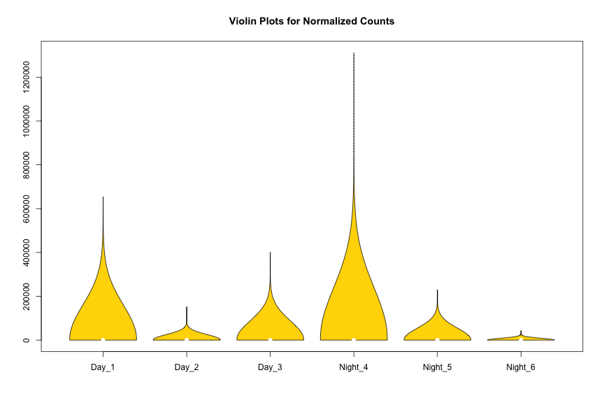

```
##      Day_1              Day_2              Day_3
##  Min.   :     0.0   Min.   :     0.0   Min.   :     0.0
##  1st Qu.:     0.0   1st Qu.:     0.0   1st Qu.:     0.0
##  Median :     0.6   Median :     0.0   Median :     0.0
##  Mean   :    63.1   Mean   :    27.5   Mean   :    43.5
##  3rd Qu.:     1.8   3rd Qu.:     1.5   3rd Qu.:     1.7
##  Max.   :654306.4   Max.   :152366.4   Max.   :400933.8
##     Night_4             Night_5             Night_6
##  Min.   :      0.0   Min.   :     0.00   Min.   :    0.00
##  1st Qu.:      0.0   1st Qu.:     0.00   1st Qu.:    0.00
##  Median :      0.0   Median :     0.44   Median :    0.39
##  Mean   :    122.1   Mean   :    25.86   Mean   :   14.06
##  3rd Qu.:      3.0   3rd Qu.:     1.32   3rd Qu.:    1.18
##  Max.   :1311227.4   Max.   :230015.70   Max.   :43083.85
```

\newpage

## Rank Abundance

Plotting Rank Abundance for top 500 genes.

### Day vs Night

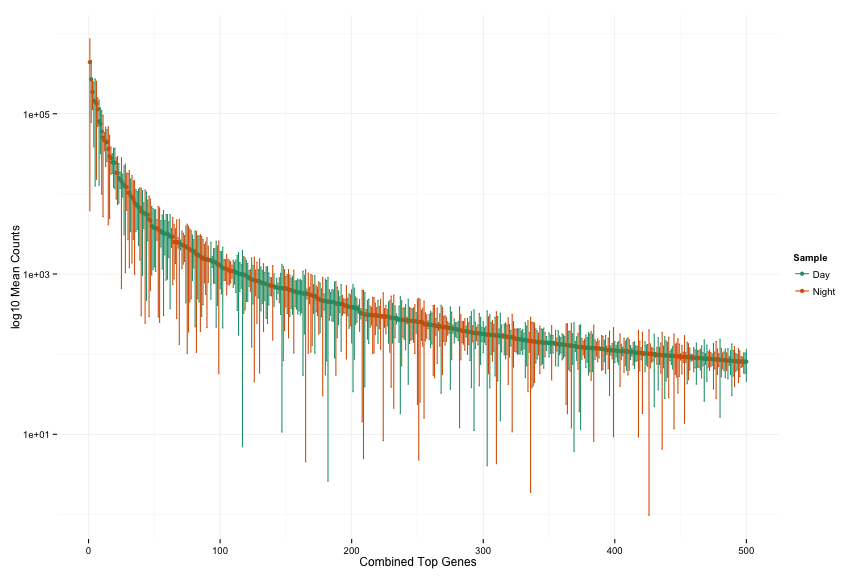

\newpage

## Differential Expression

### Removing Batch Effects

Differential expression was calculater using the DESeq2 wrapper function over 4 processors.

```
## Number of significant surrogate variables is:  2
## Iteration (out of 5 ):1  2  3  4  5
```

## Results after removing batch effects

```
## DataFrame with 6 rows and 2 columns
##                        type                                    description
##                 <character>                                    <character>
## baseMean       intermediate      mean of normalized counts for all samples
## log2FoldChange      results log2 fold change (MAP): condition Day vs Night
## lfcSE               results         standard error: condition Day vs Night
## stat                results         Wald statistic: condition Day vs Night
## pvalue              results      Wald test p-value: condition Day vs Night
## padj                results                           BH adjusted p-values
```

```
##
## out of 26544 with nonzero total read count
## adjusted p-value < 0.1
## LFC > 0 (up)     : 53, 0.2%
## LFC < 0 (down)   : 6, 0.023%
## outliers [1]     : 0, 0%
## low counts [2]   : 25216, 95%
## (mean count < 9.9)
## [1] see 'cooksCutoff' argument of ?results
## [2] see 'independentFiltering' argument of ?results
```

\newpage

### P-Value Histogram

Another useful diagnostic plot is the histogram of the p values.

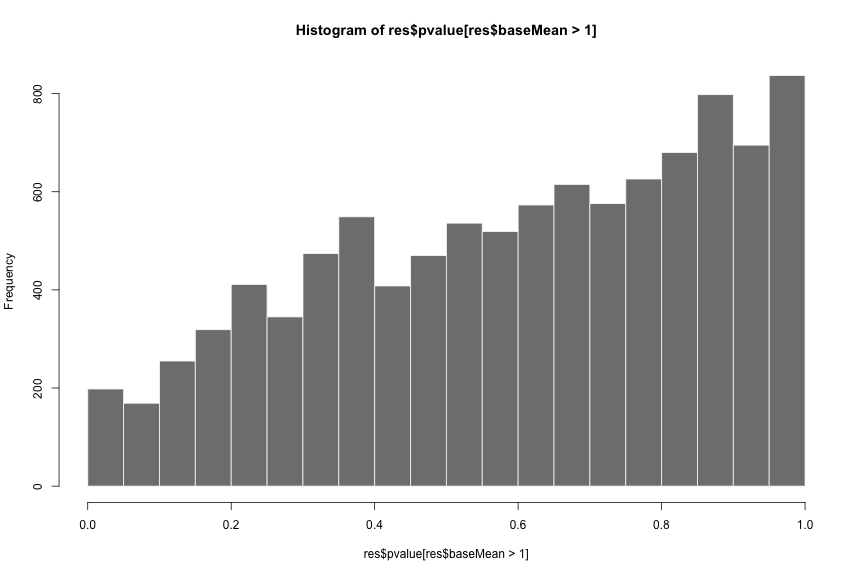

\newpage

## Significant Genes

Number of genes found to have significant differential expression:

```
## [1] 59
```

We subset the results table to these genes and then sort it by the log2 fold change estimate to get the significant genes with the strongest down-regulation.

```
## log2 fold change (MAP): condition Day vs Night
## Wald test p-value: condition Day vs Night
## DataFrame with 6 rows and 6 columns
##                                   baseMean log2FoldChange     lfcSE
##                                  <numeric>      <numeric> <numeric>
## scaffold_247603__MIS_1019830.5    48.50609      -4.654618 1.2542686
## scaffold_762984__MIS_10200131.2 7639.41777      -4.050471 1.0906161
## scaffold_39942__MIS_10004005.1   276.30102      -3.494161 1.0314812
## scaffold_83360__MIS_10039751.14  183.11743      -2.972512 0.9878613
## scaffold_762984__MIS_10200131.6  180.99322      -2.867104 0.9681510
## scaffold_55518__MIS_10017391.9   420.66374      -2.208370 0.7095335
##                                      stat       pvalue        padj
##                                 <numeric>    <numeric>   <numeric>
## scaffold_247603__MIS_1019830.5  -3.711022 0.0002064242 0.009452804
## scaffold_762984__MIS_10200131.2 -3.713929 0.0002040664 0.009452804
## scaffold_39942__MIS_10004005.1  -3.387518 0.0007052806 0.025313855
## scaffold_83360__MIS_10039751.14 -3.009037 0.0026207678 0.071028157
## scaffold_762984__MIS_10200131.6 -2.961422 0.0030622166 0.077879124
## scaffold_55518__MIS_10017391.9  -3.112425 0.0018555693 0.052429703
```

…and with the strongest upregulation.

```
## log2 fold change (MAP): condition Day vs Night
## Wald test p-value: condition Day vs Night
## DataFrame with 6 rows and 6 columns
##                                  baseMean log2FoldChange     lfcSE
##                                 <numeric>      <numeric> <numeric>
## scaffold_200891__MIS_10160517.7 202.26893       5.636189 1.1364677
## scaffold_12010__MIS_10012011.12 158.18084       5.442530 0.9284052
## scaffold_12010__MIS_10012011.1   45.37752       4.948319 1.0818309
## scaffold_181056__MIS_10140692.2 747.87516       4.942481 1.0328143
## scaffold_42417__MIS_10006030.1   34.06929       4.786238 1.1576507
## scaffold_34818__MIS_10034794.1   13.99243       4.699287 1.2326452
##                                      stat       pvalue         padj
##                                 <numeric>    <numeric>    <numeric>
## scaffold_200891__MIS_10160517.7  4.959392 7.071417e-07 3.130281e-04
## scaffold_12010__MIS_10012011.12  5.862236 4.566760e-09 6.064657e-06
## scaffold_12010__MIS_10012011.1   4.574023 4.784483e-06 1.058966e-03
## scaffold_181056__MIS_10140692.2  4.785450 1.706050e-06 4.531270e-04
## scaffold_42417__MIS_10006030.1   4.134441 3.558200e-05 4.295718e-03
## scaffold_34818__MIS_10034794.1   3.812360 1.376461e-04 8.696156e-03
```

\newpage

### Summary Table

| Name | log2FoldChange | padj | IMG_Product | IMG_Source |
| --- | --- | --- | --- | --- |
| scaffold*12010*_MIS_10012011.12 | 5.442530 | 0.0000061 | NA | NA |
| scaffold*7608*_MIS_10007609.1 | 4.539691 | 0.0000416 | NA | NA |
| scaffold*200891*_MIS_10160517.7 | 5.636189 | 0.0003130 | NA | NA |
| scaffold*356736*_MIS_10195009.1 | 4.146921 | 0.0003440 | NA | NA |
| scaffold*181056*_MIS_10140692.2 | 4.942481 | 0.0004531 | NA | NA |
| scaffold*12010*_MIS_10012011.1 | 4.948319 | 0.0010590 | NA | NA |
| scaffold*356736*_MIS_10195009.4 | 3.492412 | 0.0015148 | NA | NA |
| scaffold*430758*_MIS_10197677.1 | 3.335744 | 0.0018350 | NA | NA |
| scaffold*19008*_MIS_10019009.27 | 3.296748 | 0.0025895 | NA | NA |
| scaffold*12010*_MIS_10012011.3 | 3.644443 | 0.0042957 | NA | NA |
| scaffold*42417*_MIS_10006030.1 | 4.786238 | 0.0042957 | NA | NA |
| scaffold*195616*_MIS_10155245.4 | 3.482549 | 0.0045960 | NA | NA |
| scaffold*41583*_MIS_10036250.27 | 3.715213 | 0.0050183 | NA | NA |
| scaffold*356736*_MIS_10195009.2 | 3.380150 | 0.0055344 | NA | NA |
| scaffold*12010*_MIS_10012011.7 | 3.869782 | 0.0059244 | NA | NA |
| scaffold*162064*_MIS_10121714.1 | 4.090441 | 0.0079665 | NA | NA |
| scaffold*19008*_MIS_10019009.26 | 3.647369 | 0.0079665 | NA | NA |
| scaffold*19008*_MIS_10019009.28 | 2.907916 | 0.0079665 | NA | NA |
| scaffold*232359*_MIS_10185986.7 | 3.174997 | 0.0079665 | NA | NA |
| scaffold*163615*_MIS_10123264.4 | 3.888927 | 0.0086048 | NA | NA |
| scaffold*242878*_MIS_10186954.9 | 2.969437 | 0.0086962 | NA | NA |
| scaffold*34818*_MIS_10034794.1 | 4.699287 | 0.0086962 | NA | NA |
| scaffold*133743*_MIS_10093445.6 | 3.220367 | 0.0087786 | NA | NA |
| scaffold*19008*_MIS_10019009.29 | 2.630435 | 0.0087786 | NA | NA |
| scaffold*6544*_MIS_10006545.32 | 3.239039 | 0.0087786 | NA | NA |
| scaffold*748781*_MIS_10200104.4 | 3.097421 | 0.0087786 | NA | NA |
| scaffold*23846*_MIS_10023847.20 | 4.320381 | 0.0094528 | NA | NA |
| scaffold*247603*_MIS_1019830.5 | -4.654618 | 0.0094528 | Curlin associated repeat | pfam07012 |
| scaffold*762984*_MIS_10200131.2 | -4.050471 | 0.0094528 | Diacylglycerol acyltransferase | pfam03982 |
| scaffold*12010*_MIS_10012011.8 | 3.078971 | 0.0129999 | NA | NA |
| scaffold*12010*_MIS_10012011.4 | 3.191382 | 0.0134504 | NA | NA |
| scaffold*140713*_MIS_10100395.5 | 2.676440 | 0.0134504 | NA | NA |
| scaffold*36112*_MIS_10001001.11 | 3.299193 | 0.0145517 | NA | NA |
| scaffold*425595*_MIS_1167750.1 | 2.646232 | 0.0156805 | NA | NA |
| scaffold*142012*_MIS_10040323.5 | 3.543329 | 0.0190062 | NA | NA |
| scaffold*200195*_MIS_10159822.1 | 3.232287 | 0.0190062 | NA | NA |
| scaffold*39942*_MIS_10004005.1 | -3.494161 | 0.0253139 | NA | NA |
| scaffold*232359*_MIS_10185986.6 | 3.107126 | 0.0284879 | NA | NA |
| scaffold*276564*_MIS_10189820.1 | 2.934461 | 0.0285565 | NA | NA |
| scaffold*407786*_MIS_10197014.2 | 2.483188 | 0.0285565 | NA | NA |
| scaffold*138956*_MIS_10098641.7 | 2.730239 | 0.0305307 | NA | NA |
| scaffold*12010*_MIS_10012011.15 | 2.874866 | 0.0371092 | NA | NA |
| scaffold*230594*_MIS_10185835.2 | 2.496583 | 0.0470046 | NA | NA |
| scaffold*622706*_MIS_1174630.1 | 2.806595 | 0.0506007 | NA | NA |
| scaffold*113303*_MIS_10073104.2 | 2.596039 | 0.0516996 | NA | NA |
| scaffold*55518*_MIS_10017391.9 | -2.208370 | 0.0524297 | Phycobilisome protein | pfam00502 |
| scaffold*778707*_MIS_1178057.1 | 2.393790 | 0.0524297 | NA | NA |
| scaffold*47856*_MIS_10037233.11 | 2.433313 | 0.0667004 | NA | NA |
| scaffold*83360*_MIS_10039751.14 | -2.972512 | 0.0710282 | NA | NA |
| scaffold*564989*_MIS_10199597.1 | 2.607946 | 0.0754694 | NA | NA |
| scaffold*654999*_MIS_10199933.4 | 2.624083 | 0.0754694 | NA | NA |
| scaffold*34818*_MIS_10034794.3 | 2.506195 | 0.0778791 | NA | NA |
| scaffold*762984*_MIS_10200131.6 | -2.867104 | 0.0778791 | NA | NA |
| scaffold*92040*_MIS_10052095.5 | 2.656372 | 0.0912172 | NA | NA |
| scaffold*34818*_MIS_10034794.2 | 2.486534 | 0.0975790 | NA | NA |
| scaffold*407786*_MIS_10197014.1 | 2.102636 | 0.0975790 | NA | NA |
| scaffold*5754*_MIS_10005755.3 | 3.804303 | 0.0975790 | NA | NA |
| scaffold*65654*_MIS_10026723.10 | 2.717280 | 0.0975790 | NA | NA |
| scaffold*74783*_MIS_10035344.4 | 2.933591 | 0.0975790 | NA | NA |

\newpage

### Log2Fold vs Rank(p-value adjusted) Plot

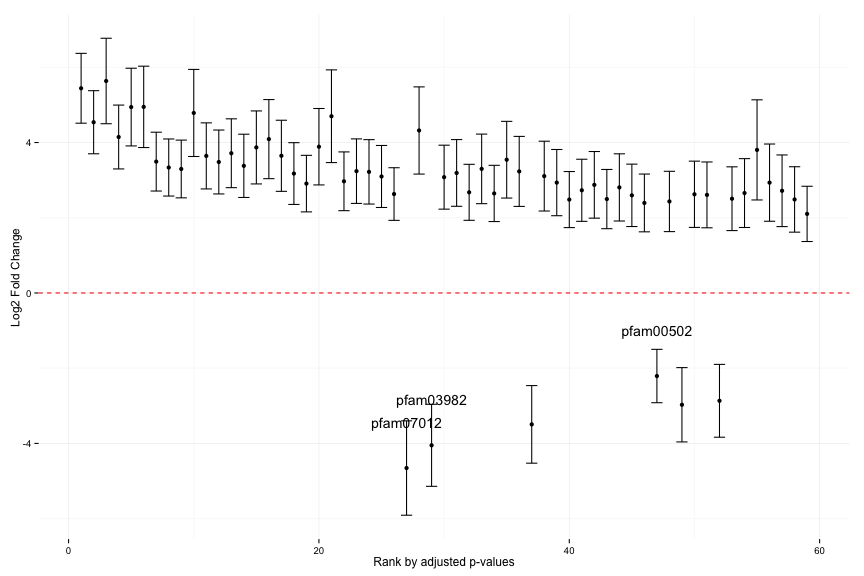

\newpage

### Volcano (log10(padj) vs log2FoldChange)

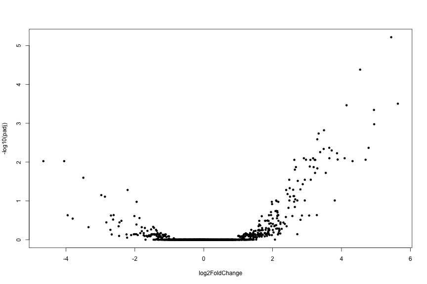

\newpage